# Lending Club Loan Data Analysis - Educational Loans

The following are some of the largest Fintech lenders: LendingClub Corporation, SOFI Lending Corp, Avant Credit Corporation, LoanDepot.com, Upstart Network Inc, and Cashcall. I looked at the two research papers and a different one I kept running into titled "Fintech Borrowers: Lax-Screening or Cream-Skimming?" by Di Maggio, Marco, and Yao, Vincent. I have attached the paper to the email that this is attached to, as well. In their working paper, they used the TransUnion dataset for various consumer credit reports and performed a comparison against Fintech lenders and traditional bank lenders. This analysis looks at loans granted for educational purposes. The data I will be using is the 2007-2015 Lending Club data for loan acceptances. There is a dataset for rejected loans that I will continue to analyze. Also, the dataset includes an "OTHER" category. Within that category, I will look for user-entered descriptions of their loan to identify if it could also fall under the "EDUCATIONAL" category. Additional features include credit scores, number of finance inquiries, address including zip codes, and state, and collections, among others. A data dictionary is provided in a separate file.

## Exploratory Data Analysis & Descriptive Statistics

We will be loading the relevant libraries and Lending Club dataset.

```python
import numpy as np
import pandas as pd
import matplotlib.pyplot as plt
import seaborn as sns

%matplotlib inline
```

```python
lending_club = pd.read_csv('loan.csv')
print('(Rows, Columns) in the data set: ',lending_club.shape)
```

```
(Rows, Columns) in the data set:  (2260668, 145)
```

### Original Variables

The data set is comprised of 145 variables, some of which are used for tracking the loan performance. I will gather the relevant variables that pertain to the loan application process. If there are other variables that are pertinent to the analysis, I will include them upon a review of my analysis.

```python
column_list = []
for column in lending_club:
    column_list.append(column)

for i in range(int(len(column_list)/4)+1):
    print(", ".join(column_list[i*4:(i+1)*4]))
```

```
id, member_id, loan_amnt, funded_amnt
funded_amnt_inv, term, int_rate, installment
grade, sub_grade, emp_title, emp_length
home_ownership, annual_inc, verification_status, issue_d
loan_status, pymnt_plan, url, desc
purpose, title, zip_code, addr_state
dti, delinq_2yrs, earliest_cr_line, inq_last_6mths
mths_since_last_delinq, mths_since_last_record, open_acc, pub_rec
revol_bal, revol_util, total_acc, initial_list_status
out_prncp, out_prncp_inv, total_pymnt, total_pymnt_inv
total_rec_prncp, total_rec_int, total_rec_late_fee, recoveries
collection_recovery_fee, last_pymnt_d, last_pymnt_amnt, next_pymnt_d
last_credit_pull_d, collections_12_mths_ex_med, mths_since_last_major_derog, policy_code
application_type, annual_inc_joint, dti_joint, verification_status_joint
acc_now_delinq, tot_coll_amt, tot_cur_bal, open_acc_6m
open_act_il, open_il_12m, open_il_24m, mths_since_rcnt_il
total_bal_il, il_util, open_rv_12m, open_rv_24m
max_bal_bc, all_util, total_rev_hi_lim, inq_fi
total_cu_tl, inq_last_12m, acc_open_past_24mths, avg_cur_bal
bc_open_to_buy, bc_util, chargeoff_within_12_mths, delinq_amnt
mo_sin_old_il_acct, mo_sin_old_rev_tl_op, mo_sin_rcnt_rev_tl_op, mo_sin_rcnt_tl
mort_acc, mths_since_recent_bc, mths_since_recent_bc_dlq, mths_since_recent_inq
mths_since_recent_revol_delinq, num_accts_ever_120_pd, num_actv_bc_tl, num_actv_rev_tl
num_bc_sats, num_bc_tl, num_il_tl, num_op_rev_tl
num_rev_accts, num_rev_tl_bal_gt_0, num_sats, num_tl_120dpd_2m
num_tl_30dpd, num_tl_90g_dpd_24m, num_tl_op_past_12m, pct_tl_nvr_dlq
percent_bc_gt_75, pub_rec_bankruptcies, tax_liens, tot_hi_cred_lim
total_bal_ex_mort, total_bc_limit, total_il_high_credit_limit, revol_bal_joint
sec_app_earliest_cr_line, sec_app_inq_last_6mths, sec_app_mort_acc, sec_app_open_acc
sec_app_revol_util, sec_app_open_act_il, sec_app_num_rev_accts, sec_app_chargeoff_within_12_mths
sec_app_collections_12_mths_ex_med, sec_app_mths_since_last_major_derog, hardship_flag, hardship_type
hardship_reason, hardship_status, deferral_term, hardship_amount
hardship_start_date, hardship_end_date, payment_plan_start_date, hardship_length
hardship_dpd, hardship_loan_status, orig_projected_additional_accrued_interest, hardship_payoff_balance_amount
hardship_last_payment_amount, disbursement_method, debt_settlement_flag, debt_settlement_flag_date
settlement_status, settlement_date, settlement_amount, settlement_percentage
settlement_term
```

### Missing Values

Looking a summary of all the variables of the dataset, we can see that there is a lot of missing data for certain variables. As we saw before, there are about 2260668 enteries in the dataset. About half of the dataset only contains that amount. Some of these variables, however, are not relevant to our analysis. 'id' and 'member_id' are also missing all the values from the dataset I was able to gather. There are other datasets on the internet but do not have as many entries as this dataset. Futhermore, I would like to only analyze data pertaining to education. I will filter out the dataset relating to education as the purpose. All enteries seem to have this variable filled out so I will futher my filtering after the initial slice of the data.

```python
#checking for missing values

lending_club.info(null_counts=True,verbose=True)
```

```
<class 'pandas.core.frame.DataFrame'>
RangeIndex: 2260668 entries, 0 to 2260667
Data columns (total 145 columns):
id                                            0 non-null float64
member_id                                     0 non-null float64
loan_amnt                                     2260668 non-null int64
funded_amnt                                   2260668 non-null int64
funded_amnt_inv                               2260668 non-null float64
term                                          2260668 non-null object
int_rate                                      2260668 non-null float64
installment                                   2260668 non-null float64
grade                                         2260668 non-null object
sub_grade                                     2260668 non-null object
emp_title                                     2093699 non-null object
emp_length                                    2113761 non-null object
home_ownership                                2260668 non-null object
annual_inc                                    2260664 non-null float64
verification_status                           2260668 non-null object
issue_d                                       2260668 non-null object
loan_status                                   2260668 non-null object
pymnt_plan                                    2260668 non-null object
url                                           0 non-null float64
desc                                          126067 non-null object
purpose                                       2260668 non-null object
title                                         2237343 non-null object
zip_code                                      2260667 non-null object
addr_state                                    2260668 non-null object
dti                                           2258957 non-null float64
delinq_2yrs                                   2260639 non-null float64
earliest_cr_line                              2260639 non-null object
inq_last_6mths                                2260638 non-null float64
mths_since_last_delinq                        1102166 non-null float64
mths_since_last_record                        359156 non-null float64
open_acc                                      2260639 non-null float64
pub_rec                                       2260639 non-null float64
revol_bal                                     2260668 non-null int64
revol_util                                    2258866 non-null float64
total_acc                                     2260639 non-null float64
initial_list_status                           2260668 non-null object
out_prncp                                     2260668 non-null float64
```

[output cut: 95 more lines]

```
hardship_dpd                                  10613 non-null float64
hardship_loan_status                          10613 non-null object
orig_projected_additional_accrued_interest    8426 non-null float64
hardship_payoff_balance_amount                10613 non-null float64
hardship_last_payment_amount                  10613 non-null float64
disbursement_method                           2260668 non-null object
debt_settlement_flag                          2260668 non-null object
debt_settlement_flag_date                     33056 non-null object
settlement_status                             33056 non-null object
settlement_date                               33056 non-null object
settlement_amount                             33056 non-null float64
settlement_percentage                         33056 non-null float64
settlement_term                               33056 non-null float64
dtypes: float64(105), int64(4), object(36)
memory usage: 2.4+ GB
```

## Pupose - Different Catagories

There are only 14 categories among all the 2+ million entries. I will only be using the "OTHER" and "EDUCATIONAL" catagories for further analysis. I want to see the distribution and percentage each catagory. I will gather the number of records for each catagory and divided it by the total amount of records to find each percentage.

```python
purpose_list = list(lending_club['purpose'].unique())
for purpose in purpose_list:
    print(purpose)
```

```
debt_consolidation
credit_card
house
car
other
vacation
home_improvement
small_business
major_purchase
medical
renewable_energy
moving
wedding
educational
```

```python
total_entries = lending_club.shape[0]
perc_list = []
for purpose in purpose_list:
    num_loans = lending_club[lending_club['purpose'] == purpose].shape[0]
    purpose_percent = float(num_loans)/float(total_entries)
    perc_list.append(purpose_percent)
```

```python
purpose_dict = dict(zip(purpose_list, perc_list))
purpose_dict
```

```
{'debt_consolidation': 0.565265222491759,
 'credit_card': 0.2286806377583971,
 'house': 0.006253019019157169,
 'car': 0.010622081614814736,
 'other': 0.06168088370340094,
 'vacation': 0.006867439181693199,
 'home_improvement': 0.0665542220264099,
 'small_business': 0.010921108274191522,
 'major_purchase': 0.022314200935298772,
 'medical': 0.012159237888977948,
 'renewable_energy': 0.0006391916017743428,
 'moving': 0.006813472831924015,
 'wedding': 0.0010417274893969393,
 'educational': 0.00018755518280437464}
```

**Break Down of each catagory**

As we can see from the breakdown above, loans with the purpose of "EDUCATIONAL" make up less than 1 pecent of all the loans in this dataset. However, there is still about 6% within the "OTHER" category. We can utilize the 'desc' column to see if the text or description of loan describes anything regarding "Student Loans".

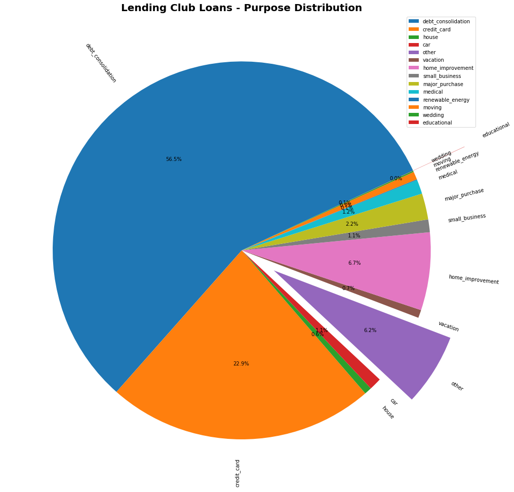

```python
font_title = {'weight': 'bold', 'size': 20,}
explode = [0,0,0,0,.2,0,0,0,0,0,0,0,0,.3]


plt.figure(figsize=(14,14))
plt.pie(perc_list,labels=purpose_list, explode=explode, autopct='%1.1f%%', rotatelabels=True, startangle=25)
plt.title('Lending Club Loans - Purpose Distribution',fontdict=font_title,loc='center')
plt.legend()
plt.tight_layout();
```

### Limited Data

There is limited data in the Lending Club dataset regarding loans for the puposes of education. Less than 1% of loans in the dataset are for the purpose of education. Within the "OTHER" category, it is a similar case. Only about 7144 enteries of the 139440 entries catagorized as "OTHER" have a description. Within those 7144, there limited instances of loans regarding "Student Loans".

```python
lending_club[lending_club['purpose'] == 'educational'].shape[0]
```

```
424
```

```python
lending_club[lending_club['purpose'] == 'other'].shape[0]
```

```
139440
```

```python
other_data = lending_club[lending_club['purpose'] == 'other']
with_desc = other_data.desc.count()
print('Only {} entries with user input descriotion'.format(with_desc))
```

```
Only 7144 entries with user input descriotion
```

```python
edu_count = other_data['desc'].str.contains('education').sum()
if edu_count > 0:
    print ("There are {m} mentions of education in descriptions of loans.".format(m = edu_count))
```

```
There are 48 mentions of education in descriptions of loans.
```

```python
student_count = other_data['desc'].str.contains('student').sum()
if student_count > 0:
    print ("There are {m} mentions of student in descriptions of loans.".format(m = student_count))
```

```
There are 113 mentions of student in descriptions of loans.
```

```python
tuition_count = other_data['desc'].str.contains('tuition').sum()
if tuition_count > 0:
    print ("There are {m} mentions of tuition in descriptions of loans.".format(m = tuition_count))
```

```
There are 39 mentions of tuition in descriptions of loans.
```

```python
degree_count = other_data['desc'].str.contains('degree').sum()
if degree_count > 0:
    print ("There are {m} mentions of degree in descriptions of loans.".format(m = degree_count))
```

```
There are 40 mentions of degree in descriptions of loans.
```

```python
educational = lending_club[lending_club['purpose'] == 'educational']
educational.shape
```

```
(424, 145)
```

```python
educational.info(verbose=True, null_counts=True)
```

```
<class 'pandas.core.frame.DataFrame'>
Int64Index: 424 entries, 1253433 to 2156631
Data columns (total 145 columns):
id                                            0 non-null float64
member_id                                     0 non-null float64
loan_amnt                                     424 non-null int64
funded_amnt                                   424 non-null int64
funded_amnt_inv                               424 non-null float64
term                                          424 non-null object
int_rate                                      424 non-null float64
installment                                   424 non-null float64
grade                                         424 non-null object
sub_grade                                     424 non-null object
emp_title                                     392 non-null object
emp_length                                    415 non-null object
home_ownership                                424 non-null object
annual_inc                                    424 non-null float64
verification_status                           424 non-null object
issue_d                                       424 non-null object
loan_status                                   424 non-null object
pymnt_plan                                    424 non-null object
url                                           0 non-null float64
desc                                          382 non-null object
purpose                                       424 non-null object
title                                         422 non-null object
zip_code                                      424 non-null object
addr_state                                    424 non-null object
dti                                           424 non-null float64
delinq_2yrs                                   424 non-null float64
earliest_cr_line                              424 non-null object
inq_last_6mths                                424 non-null float64
mths_since_last_delinq                        185 non-null float64
mths_since_last_record                        72 non-null float64
open_acc                                      424 non-null float64
pub_rec                                       424 non-null float64
revol_bal                                     424 non-null int64
revol_util                                    421 non-null float64
total_acc                                     424 non-null float64
initial_list_status                           424 non-null object
out_prncp                                     424 non-null float64
```

[output cut: 95 more lines]

```
hardship_dpd                                  0 non-null float64
hardship_loan_status                          0 non-null object
orig_projected_additional_accrued_interest    0 non-null float64
hardship_payoff_balance_amount                0 non-null float64
hardship_last_payment_amount                  0 non-null float64
disbursement_method                           424 non-null object
debt_settlement_flag                          424 non-null object
debt_settlement_flag_date                     2 non-null object
settlement_status                             2 non-null object
settlement_date                               2 non-null object
settlement_amount                             2 non-null float64
settlement_percentage                         2 non-null float64
settlement_term                               2 non-null float64
dtypes: float64(105), int64(4), object(36)
memory usage: 483.6+ KB
```

```python
drop_columns = []

for column in educational:
    nulls = educational[column].isnull().sum()
    if nulls >=50:
        drop_columns.append(column)

print(drop_columns)
```

```
['id', 'member_id', 'url', 'mths_since_last_delinq', 'mths_since_last_record', 'next_pymnt_d', 'mths_since_last_major_derog', 'annual_inc_joint', 'dti_joint', 'verification_status_joint', 'tot_coll_amt', 'tot_cur_bal', 'open_acc_6m', 'open_act_il', 'open_il_12m', 'open_il_24m', 'mths_since_rcnt_il',…
```

## Deeper Dive

This section will be a deeper dive into some of the underlying distributions of certain variables left in the dataset. I want to consider FICO or any other credit score found by LendingClub. However, the data source I gathered did not provide the users FICO or credit score. I will be analyzing the variables that fall in line with the paper listed at the beginning of this analysis. I also believe it would be essential to look at the change over time. We can look at issue_date for the difference in loan characteristics over time.

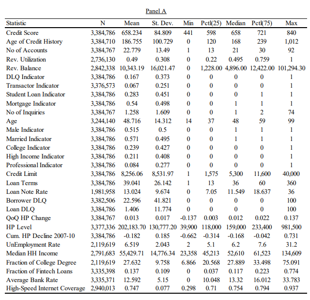

```python
from IPython.display import Image
Image(filename='variables.png')
```

```python
educational_dropped = educational.drop(columns=drop_columns)
educational_dropped.info(verbose=True, null_counts=True)
```

```
<class 'pandas.core.frame.DataFrame'>
Int64Index: 424 entries, 1253433 to 2156631
Data columns (total 53 columns):
loan_amnt                     424 non-null int64
funded_amnt                   424 non-null int64
funded_amnt_inv               424 non-null float64
term                          424 non-null object
int_rate                      424 non-null float64
installment                   424 non-null float64
grade                         424 non-null object
sub_grade                     424 non-null object
emp_title                     392 non-null object
emp_length                    415 non-null object
home_ownership                424 non-null object
annual_inc                    424 non-null float64
verification_status           424 non-null object
issue_d                       424 non-null object
loan_status                   424 non-null object
pymnt_plan                    424 non-null object
desc                          382 non-null object
purpose                       424 non-null object
title                         422 non-null object
zip_code                      424 non-null object
addr_state                    424 non-null object
dti                           424 non-null float64
delinq_2yrs                   424 non-null float64
earliest_cr_line              424 non-null object
inq_last_6mths                424 non-null float64
open_acc                      424 non-null float64
pub_rec                       424 non-null float64
revol_bal                     424 non-null int64
revol_util                    421 non-null float64
total_acc                     424 non-null float64
initial_list_status           424 non-null object
out_prncp                     424 non-null float64
out_prncp_inv                 424 non-null float64
total_pymnt                   424 non-null float64
total_pymnt_inv               424 non-null float64
total_rec_prncp               424 non-null float64
total_rec_int                 424 non-null float64
total_rec_late_fee            424 non-null float64
recoveries                    424 non-null float64
collection_recovery_fee       424 non-null float64
last_pymnt_d                  421 non-null object
last_pymnt_amnt               424 non-null float64
last_credit_pull_d            424 non-null object
collections_12_mths_ex_med    414 non-null float64
policy_code                   424 non-null int64
application_type              424 non-null object
acc_now_delinq                424 non-null float64
chargeoff_within_12_mths      414 non-null float64
delinq_amnt                   424 non-null float64
tax_liens                     416 non-null float64
hardship_flag                 424 non-null object
disbursement_method           424 non-null object
debt_settlement_flag          424 non-null object
dtypes: float64(26), int64(4), object(23)
memory usage: 178.9+ KB
```

### Numerical Values and Categorical Values

Upon my first initial look at the numerical values of the dataset, certain variables will require outlier manipulation. In other cases, certain variables do not have much variation.

- tax_liens
- delinq_amnt
- chargeoff_within_12_months
- collections_12_mnths_ex_med
- policy code

We can also break down the limited dataset into two numerical and categorical values. After further analysis of the descriptions of each loan, individual educational loans can also be used for technical skills such as Yoga Instructor, Welding, etc. Some cases of loans within this category are also used to consolidate their student debt or to help pay for a few miscellaneous expenses.

```python
educational_dropped.describe().transpose()
```

|  | count | mean | std | min | 25% | 50% | 75% | max |
| --- | --- | --- | --- | --- | --- | --- | --- | --- |
| loan_amnt | 424.0 | 6614.622642 | 5087.953508 | 500.00 | 3000.000000 | 5000.000000 | 8500.000000 | 25000.000000 |
| funded_amnt | 424.0 | 6511.733491 | 4991.189874 | 500.00 | 3000.000000 | 5000.000000 | 8400.000000 | 25000.000000 |
| funded_amnt_inv | 424.0 | 5069.612080 | 4686.329438 | 0.00 | 1800.000000 | 3987.500000 | 6733.755006 | 24862.764164 |
| int_rate | 424.0 | 12.142146 | 2.765914 | 6.00 | 10.237500 | 12.210000 | 13.790000 | 21.450000 |
| installment | 424.0 | 214.345991 | 167.334283 | 15.67 | 97.490000 | 168.765000 | 271.520000 | 861.880000 |
| annual_inc | 424.0 | 51280.175896 | 41244.501597 | 3300.00 | 24999.000000 | 40000.000000 | 65500.000000 | 425000.000000 |
| dti | 424.0 | 11.269033 | 6.836974 | 0.00 | 5.460000 | 11.025000 | 16.290000 | 29.740000 |
| delinq_2yrs | 424.0 | 0.183962 | 0.594798 | 0.00 | 0.000000 | 0.000000 | 0.000000 | 7.000000 |
| inq_last_6mths | 424.0 | 1.801887 | 2.320307 | 0.00 | 0.000000 | 1.000000 | 2.000000 | 16.000000 |
| open_acc | 424.0 | 8.693396 | 5.271840 | 1.00 | 5.000000 | 8.000000 | 11.000000 | 51.000000 |
| pub_rec | 424.0 | 0.047170 | 0.212252 | 0.00 | 0.000000 | 0.000000 | 0.000000 | 1.000000 |
| revol_bal | 424.0 | 10369.735849 | 21689.438405 | 0.00 | 1146.750000 | 3488.000000 | 8926.500000 | 226567.000000 |
| revol_util | 421.0 | 40.080048 | 29.717484 | 0.00 | 12.500000 | 38.500000 | 63.300000 | 102.700000 |
| total_acc | 424.0 | 17.500000 | 11.983637 | 1.00 | 8.000000 | 15.000000 | 24.000000 | 77.000000 |
| out_prncp | 424.0 | 9.686675 | 199.460836 | 0.00 | 0.000000 | 0.000000 | 0.000000 | 4107.150000 |
| out_prncp_inv | 424.0 | 9.686675 | 199.460836 | 0.00 | 0.000000 | 0.000000 | 0.000000 | 4107.150000 |
| total_pymnt | 424.0 | 6656.942667 | 5537.402539 | 45.00 | 2643.027753 | 5395.561728 | 8784.051703 | 30392.352708 |
| total_pymnt_inv | 424.0 | 5225.862241 | 5162.920807 | 0.00 | 1625.887500 | 3947.345000 | 6958.652500 | 30205.020000 |
| total_rec_prncp | 424.0 | 5544.447476 | 4818.676606 | 0.00 | 2000.000000 | 4320.945000 | 7276.285000 | 25000.000000 |
| total_rec_int | 424.0 | 1001.819151 | 919.426931 | 0.00 | 359.135000 | 757.120000 | 1333.172500 | 5392.350000 |
| total_rec_late_fee | 424.0 | 3.232499 | 11.302091 | 0.00 | 0.000000 | 0.000000 | 0.000000 | 123.240000 |
| recoveries | 424.0 | 107.443754 | 698.731938 | 0.00 | 0.000000 | 0.000000 | 0.000000 | 10002.320000 |
| collection_recovery_fee | 424.0 | 27.720387 | 237.068440 | 0.00 | 0.000000 | 0.000000 | 0.000000 | 3500.480000 |
| last_pymnt_amnt | 424.0 | 1166.252925 | 2626.382820 | 0.00 | 90.192500 | 226.220000 | 854.600000 | 23592.410000 |
| collections_12_mths_ex_med | 414.0 | 0.000000 | 0.000000 | 0.00 | 0.000000 | 0.000000 | 0.000000 | 0.000000 |
| policy_code | 424.0 | 1.000000 | 0.000000 | 1.00 | 1.000000 | 1.000000 | 1.000000 | 1.000000 |
| acc_now_delinq | 424.0 | 0.002358 | 0.048564 | 0.00 | 0.000000 | 0.000000 | 0.000000 | 1.000000 |
| chargeoff_within_12_mths | 414.0 | 0.000000 | 0.000000 | 0.00 | 0.000000 | 0.000000 | 0.000000 | 0.000000 |
| delinq_amnt | 424.0 | 0.000000 | 0.000000 | 0.00 | 0.000000 | 0.000000 | 0.000000 | 0.000000 |
| tax_liens | 416.0 | 0.000000 | 0.000000 | 0.00 | 0.000000 | 0.000000 | 0.000000 | 0.000000 |

```python
# Distribution graphs (histogram/bar graph) of column data
def plotPerColumnDistribution(df, nGraphShown, nGraphPerRow):
    nunique = df.nunique()
    df = df[[col for col in df if nunique[col] > 1 and nunique[col] < 50]] # and nunique[col] < 50 For displaying purposes, pick columns that have between 1 and 50 unique values
    nRow, nCol = df.shape
    columnNames = list(df)
    nGraphRow = (nCol + nGraphPerRow - 1) / nGraphPerRow
    plt.figure(num = None, figsize = (6 * nGraphPerRow, 8 * nGraphRow), dpi = 80, facecolor = 'w', edgecolor = 'k')
    for i in range(min(nCol, nGraphShown)):
        plt.subplot(nGraphRow, nGraphPerRow, i + 1)
        columnDf = df.iloc[:, i]
        if (not np.issubdtype(type(columnDf.iloc[0]), np.number)):
            valueCounts = columnDf.value_counts()
            valueCounts.plot.bar()
        else:
            columnDf.hist()
        plt.ylabel('counts')
        plt.xticks(rotation = 90)
        plt.title('{}'.format(columnNames[i]))
    plt.tight_layout(pad = 2, w_pad = 1.0, h_pad = 1.0)
    plt.show()
```

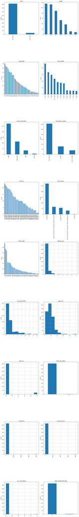

```python
plotPerColumnDistribution(educational_dropped,educational_dropped.size,2);
```

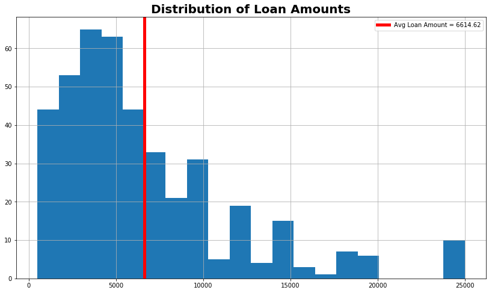

```python
plt.figure(figsize=(14,8))
educational_dropped.loan_amnt.hist(bins=20)
plt.title('Distribution of Loan Amounts',fontdict=font_title)
plt.axvline(x=6614.62,linewidth=5, color='r', label="Avg Loan Amount = 6614.62")
plt.legend();
```

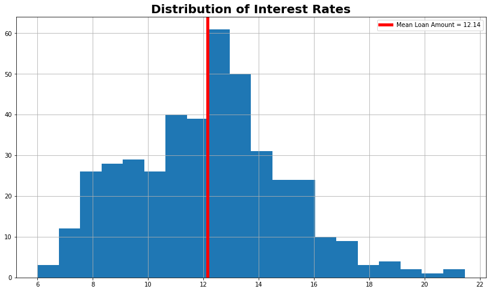

```python
plt.figure(figsize=(14,8))
educational_dropped.int_rate.hist(bins=20)
plt.title('Distribution of Interest Rates',fontdict=font_title)
plt.axvline(x=12.14,linewidth=5, color='r', label="Mean Loan Amount = 12.14")
plt.legend();
```

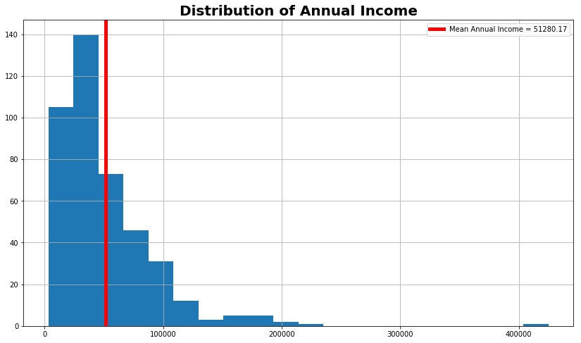

```python
plt.figure(figsize=(14,8))
educational_dropped.annual_inc.hist(bins=20)
plt.title('Distribution of Annual Income',fontdict=font_title)
plt.axvline(x=51280.17,linewidth=5, color='r', label="Mean Annual Income = 51280.17")
plt.legend();
```

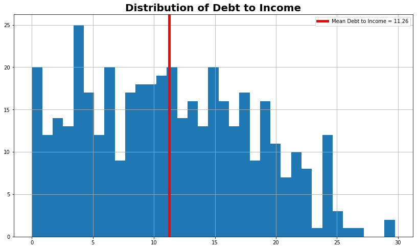

```python
plt.figure(figsize=(14,8))
educational_dropped.dti.hist(bins=35)
plt.title('Distribution of Debt to Income',fontdict=font_title)
plt.axvline(x=11.26,linewidth=5, color='r', label="Mean Debt to Income = 11.26")
plt.legend();
```

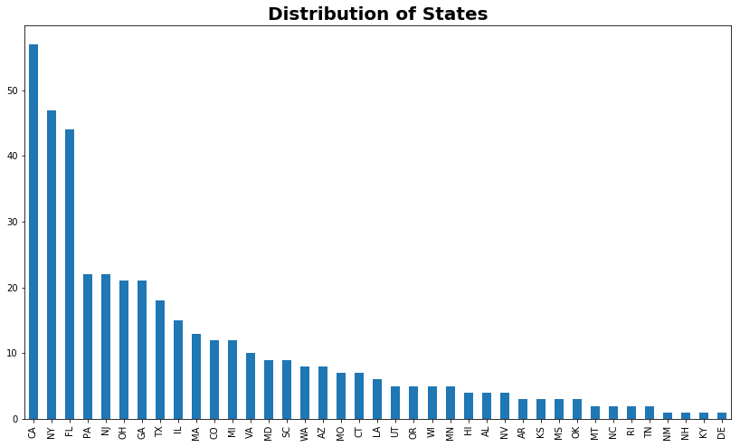

```python
plt.figure(figsize=(14,8))
educational_dropped["addr_state"].value_counts().plot('bar')
plt.title('Distribution of States',fontdict=font_title);
```

```python
print(educational_dropped["emp_title"].unique())
```

```
['President' 'Prime Time Sports Camps' 'Federal Reserve Bank of Chicago'
 'General Physics Corporation' 'Enloe Medical Center' 'Direct Data Inc'
 '914th US AIR FORCE' 'Traco MFG' 'Missouri Department of Corrections'
 "St. Vincent's Catholic Charities" nan 'Alerio Technology Group'
 'Sonnys BBQ' 'West Babylon School District' 'American Express'
 'Port Authority of NY & NJ' 'Empire State Pride Agenda' "Bloomingdale's"
 'Strategic Financial Group of California'
 'General Services Administration' 'Albert Landscaping L.L.C'
 'Divine Community Health Care Services' 'FitnessEm'
 'Norman Glavas Architects' 'Tanner Health System'
 'Noell Desiree Jewelry, LLC' 'Genesee Intermediate School District'
 'Monroe County Schools' 'First Investors Corporation'
 'Canton Public Schools' 'NPC INTERNATIONAL, INC.' 'Nicepak, Inc.'
 'Metraflex' 'c&t auto service and sears auto center' 'Chrysler LLC'
 'Bank of America' 'Dynamic Edge, Inc' 'Movietime Video, LLC'
 'Jones, Foster, Johnston & Stubbs, P.A.' 'PennMutual Life Insurance'
 'Tom Cat Bakery, Inc' 'Department Of Defense' 'BNP Paribas Fortis Bank'
 'Kforce ' 'Hilton Head Regional Medical Center' 'FOXHALL INTERNISTS'
 'Lennar Corp.' 'pathmark' "O'connor Hospital" 'mago construction company'
 'El-Macero Pharmacy' 'Stonehill College'
 'Carousel Developement & Restoration, Inc' 'US ARMY' 'armc'
 'Kerry Ingredients and Flavors' 'Porter Hills Village'
 'CHARTIS-Broker Services ' 'Salt Lake City Public Library'
 'Queens Borough Public Library' 'MediMedia U.S.A.'
 'LA FITNESS INTERNATIONAL,LLC' '7-Eleven(formerly White Hen Pantry)'
 'sport chalet' 'William Beaumont Hospital' 'Loranger International'
 'LP Speedy Spa' 'RED ROBIN' 'Upper Lakes Foods' 'ADP'
 'Family Counseling Center' 'hewlett packard' 'Wells Fargo Fanancial'
 'Securitas' 'LPL Financial' 'Apria healthcare' 'MG BROTHERS CONSTRUCTION'
 'target' 'Marist High School' 'Abercrombie & Fitch' 'Las Vegas Hilton'
 'Memorial Sloan-Kettering Cancer Center' "Mike's English School" 'Endeca'
 'Blade Technologies' 'Commentary, Inc. ' 'Touro College'
 'Presidential Airways' 'JetBlue Airways' 'Covidien'
 'MEDICAL CITY DALLAS HOSPITAL' 'WMCR' 'Employee Benefit Solutions, Inc.'
 'spa' "Jack's Family Restaurants, Inc. " 'JOHN SCIALES, MD'
 'Blockbuster Inc' 'Charles Schwab and Co.' 'Pelham School District'
 'The Home Depot' "Children's Hospital of Philadelphia" 'Emcore/JPL'
 'University of Massachusetts Amherst' 'U.S. Army' 'Accuvant Inc'
 'RBC Wealth Management' 'Portland Public Schools' 'PwC' 'Marcus Theatres'
 "Ridgewell's, Inc." 'ALLSTATE INSURANCE COMPANY' "Paddy Murphy's"
```

[output cut: 80 more lines]

```
 'GW University' 'Dutesco At' 'SPX Cooling Technologies' 'Walmart'
 'ProFlowers (Provide Commerce)' 'Life Home Care' 'Skanska' 'UCLA'
 'Army Corps of Engineers' 'Glendale Clinic' 'W&G' 'Cullum Constructors'
 'Druid Hills Bookstore' 'Gold Financial Services' 'EZ Staffing,Inc.'
 'Social Security Administration (SSA)' 'Jim Barb Realty Inc'
 'Capgemini US LLC' 'St. Charles Medical' 'Capital Noveltees'
 'GINGETTE H. BRINGMAN' 'UT MD Anderson Cancer Center' 'Express'
 'Spherion' 'boulder station hotel casino' 'E & J Hauling'
 'Broadmoor Hotel' 'Tiffany Fuller' 'Junaid Hashim MD' 'pcs2000'
 'Skyco Limited' 'Camelot Club' 'Teleperformance' 'Rouge Moira LLC'
 'US Dept of Defense -- DISA' 'A Place for growth' "A-jack's painting"
 'DHL Express' 'VENSOFT LLC' 'Business Advancement Center'
 'PGIII Services' 'MBA Team, Inc.' 'Robert Wood Johnson/ Saint Peters'
 'The Joy of Learning' "Walgreen's" 'North Carolina State University'
 'Subway' 'GA-PCOM' 'WAREHOUSE LEAD']
```

```python
pd.options.display.max_colwidth = 200
educational_dropped[['loan_amnt','desc','emp_title']].dropna().head(25)
```

|  | loan_amnt | desc | emp_title |
| --- | --- | --- | --- |
| 1253433 | 2200 | In need a little money to get me for a while after a tough semester in both graduate (clinical psychology) and law schools. Any help would be much appreciated. | President |
| 2124774 | 10500 | Borrower added on 09/29/10 > This loan will be used to supplement my income while I attend business school.<br/> Borrower added on 09/30/10 > Thank you to everyone who has funded my loan thus fa... | Federal Reserve Bank of Chicago |
| 2124881 | 5600 | I will be using this loan to attend training/school for a trade which will provide me a certificate needed to work part time and earn the money to pay back this loan and save money for the future. | General Physics Corporation |
| 2125210 | 2500 | Borrower added on 09/15/10 > Have a very stable job... been at the same job for 23 years. Need extra money to help with personal expenses.<br/> | 914th US AIR FORCE |
| 2126666 | 3400 | Borrower added on 08/03/10 > This loan is so that I can further my education and get my Bachalors in Social Work.<br/> | St. Vincent's Catholic Charities |
| 2126784 | 10000 | Borrower added on 08/02/10 > I have three years of outside sales experience in copiers and technology services. I am beginning a new position that includes more specialized product and sales ski... | Alerio Technology Group |
| 2126964 | 2000 | Borrower added on 07/27/10 > I am trying to come up with enough funds to pay for tuition and books for the Fall 2010 semester of nursing school. Any help would be appreciated, thanks!<br/> | Sonnys BBQ |
| 2127078 | 2400 | Borrower added on 07/22/10 > I have a great new job after receiving my MBA from UC Berkeley, but have a few expenses left to take care of related to school prior to receiving my first paycheck. ... | American Express |
| 2127130 | 3500 | Borrower added on 07/22/10 > The purpose of this loan is pay off the balance of my son's undergraduate education so that they can release his transcript. He has been acepted into law school and ... | Port Authority of NY & NJ |
| 2127715 | 12000 | Borrower added on 07/06/10 > Bikram Yoga Teacher Training Loan<br/> Borrower added on 07/12/10 > I have just been accepted as a student for Bikram Yoga's teacher training fall 2010 session. i h... | Bloomingdale's |
| 2127871 | 8400 | Borrower added on 06/30/10 > Paying for tuition for MBA degree.<br/> Borrower added on 06/30/10 > Will also be using funds to pay for some credit card debts accrued from hospital/doctor visits r... | Strategic Financial Group of California |
| 2127917 | 2400 | Borrower added on 06/29/10 > Need funds for child's college. FAFSA was completed, however only a little was awarded.<br/> | General Services Administration |
| 2128347 | 4000 | Borrower added on 06/16/10 > This loan is going to help me get my head a little farther above water and hopefully boost my credit rating.<br/> | Albert Landscaping L.L.C |
| 2128440 | 12000 | Borrower added on 06/15/10 > Had a discussion with my boss today and know that my job is very stable. Nice to hear that reinforcement in a tough economy. I will be consolidating some debt and ... | FitnessEm |
| 2128618 | 8400 | Borrower added on 06/08/10 > Using the loan funds to upgrade my tennis teaching and training certifications this summer to be eligible for a high salary and full-time director of tennis job at a... | Noell Desiree Jewelry, LLC |
| 2128726 | 5000 | Borrower added on 06/06/10 > To whom it may concern:<br/><br/>Three grad classes stand between me and a Masters in Counseling. Normally, I would take a Federal Student Loan, but I fall below hal... | Genesee Intermediate School District |
| 2128824 | 14000 | Borrower added on 06/03/10 > I will be using the funds to get training that I need to start my own education consulting company. I have been an educator for 8 years, previously as a teacher and... | Monroe County Schools |
| 2128904 | 5000 | Borrower added on 05/28/10 > The purpose of the loan request is to fund in part professional helicopter pilot training.<br/> | Canton Public Schools |
| 2129598 | 6000 | Borrower added on 05/11/10 > no note<br/> | Nicepak, Inc. |
| 2129677 | 18000 | Borrower added on 05/07/10 > I'm planning to use this money on education and paying off my other debts, so I have only one debt. I'm a good borrower because I'm very responsible and organized, a... | Metraflex |
| 2129678 | 6600 | Borrower added on 05/07/10 > I am a mechanic and a single dad who works two jobs and am very responcible. I want this loan so I can afford to take some refresher courses, take some A.S.E tests a... | c&t auto service and sears auto center |
| 2129685 | 6000 | Borrower added on 05/09/10 > I have been working for more than 15 years with the same company. I have a good credit score and healthy income.<br/>My daughter was accepted for a Summer Pre Colleg... | Chrysler LLC |
| 2129741 | 5000 | Borrower added on 05/06/10 > Loan will be used to fund tuition/expenses for MS/Finance Graduate Degree from Texas Tech University. Will be attending Fall 2010. Currently work for Bank of Ameri... | Bank of America |
| 2129809 | 1600 | Borrower added on 05/03/10 > I had to go to the hospital and while my insurance covered most of it, there is still more to cover. This will be for covering my hospital bill to keep my credit go... | Dynamic Edge, Inc |
| 2129840 | 4750 | Borrower added on 04/30/10 > I have recently applied and been accepted to a Montessori training institute to become a certified Montessori instructor. Because it's considered a 'vocational schoo... | Movietime Video, LLC |

```python
educational_dropped[['loan_amnt','desc','emp_title']].dropna().tail(25)
```

|  | loan_amnt | desc | emp_title |
| --- | --- | --- | --- |
| 2141593 | 5000 | I love my job and am good at it! My career has been stalled, however, for the past few years, because I need to finish my Master's Degree in order to be promoted to the next administrative level.... | UT MD Anderson Cancer Center |
| 2141610 | 2000 | I need some extra money to help pay for school expenses like rent and the difference that I pay to the school per semester. | Express |
| 2141635 | 7500 | I would like to attend CT school of Broadcasting and I have already secured $5,000.00 and need $7,440.00 more. My previous college education has been payed for by grants and myself/parents. This i... | Spherion |
| 2141656 | 14300 | Loan is to help pay off bills and go to real estate investing school. | boulder station hotel casino |
| 2141673 | 14550 | I am trying to send my wife to college and need to pay off credit card debt so she can get a student loan. She is sapose to start in January. I hope I can get it done by then. | E & J Hauling |
| 2141679 | 1000 | I am currently a culinary apprentice at the Broadmoor Hotel and need a little financial help with school expenses. I work full-time in the kitchens of the hotel, learning new and classical cuisin... | Broadmoor Hotel |
| 2141681 | 1500 | This loan will be used to cover expenses at Dillard University in New Orleans and the University of Arkansas in Fayetteville. I will be taking 2 online Spanish courses and I will be taking two ind... | Tiffany Fuller |
| 2141771 | 6000 | Hello I need to pay tuition for the next semester which should be about 3500 dollars with about 500 dollars worth of books. The rest 1000 is for meals and extra expenses that college students go ... | Junaid Hashim MD |
| 2141777 | 10000 | I need money to get through school | pcs2000 |
| 2141790 | 10000 | I am currently flying a turbo prop aircraft and have the opportunity to move up to a higher paying job if I can upgrade my pilots license by adding a jet type rating. This loan will pay for the t... | Skyco Limited |
| 2141809 | 2500 | I really would like to get a loan to help finance with the rest of my education expenses. The loan would help cover my on campus living expenses and books. Im a very hard working student and just ... | Camelot Club |
| 2141827 | 5000 | To cover the cost of tuiton and book. | Teleperformance |
| 2141830 | 9000 | To whom it may concern, I am currently a Pre-Med Student attending New York University for my B.S. The purpose of this loan is this - I usually have my college tuition taken care of by Federal & ... | Rouge Moira LLC |
| 2141852 | 8150 | I am seeking to better the loan repayment terms on a private education loan originated with Sallie Mae. | US Dept of Defense -- DISA |
| 2141856 | 5000 | I would like to have the capacity to get extra credits in the University in order to achieve my goals faster. | A Place for growth |
| 2141884 | 2400 | Please, I need to borrow $1500 for fall 2007, against earnings from part-time work and Spring school loan disbursment. | A-jack's painting |
| 2141886 | 7000 | I'm requesting this loan to fund a 7 day Master Trader Course with Velez Capital Management, LLC. The current price of the course is $6,995.00 and it is being offered next month (October 13-19, 2... | DHL Express |
| 2141889 | 12000 | I am working as an IT professional in a reputed organization. My wife is pursuing her MS. I can not bear all these expenses at a time. I will be able to pay the amount in installments. I need to p... | VENSOFT LLC |
| 2141899 | 4375 | Looking for a better interest rate than those available through other private student loan organizations. Finally set time to out finish my education, going for a BS in in Business Management. I... | Business Advancement Center |
| 2141912 | 4800 | To whom it may concern, I am currently a Journalism Student attending Hunter College in New York City for my B.A. The purpose of this loan is this - I usually have my tuition taken care of by Fed... | Rouge Moira LLC |
| 2141918 | 3000 | I have just 7 courses to complete towards earning my Bachelor of Arts Business Administration and Management. I must cover that which my Federal Student Loans will not: books, additional tuition,... | PGIII Services |
| 2141946 | 12800 | I am a computer science student, 22 years old, at UMass Lowell. I have moved out of my parent's house and need some help paying for my last two years. I will be graduating in 2009 with a Bachelor... | MBA Team, Inc. |
| 2141952 | 12000 | About me: My name is Michelle and I currently work as well as go to school full time. Coming from a Portuguez family who really only speaks portuguez I have made my ways through school and made my... | Robert Wood Johnson/ Saint Peters |
| 2141969 | 1200 | My car was damaged when I was hit by a drunk driver. My father works and my mother is currently unemployed and they can not afford to give me money to have my car fixed. If my car is not fixed the... | Walgreen's |
| 2141976 | 1800 | I am starting PhD from fall 2007. I have full scholarship that includes monthly stipend. I need few educational items, e.g. laptop, books, etc. I would be able to repay the loan amount within 6-... | North Carolina State University |

## My Thoughts

I think that that the Lending Club data is a great source to gauge fintech trends overall over broad categories of loans. However, I believe that it is not enough on its own. I will research into the TransUnion dataset that the research paper mentioned. From my initial analysis of this, I can see that this company is providing the "last dollar" loans.